# Contrôle qualité des MSC starvé et non starvé

DUPUY Mathis

10/7/2022

## Methodes

### scRNA-seq Data Processing

#### Quality Control

L’étape du controle qualité nous permet de filtrer les cellules de mauvaises qualités afin de faciliter la suite des analyses.

##### Nombre de cellules

Nos librairies ont été formé à partir d’échantillon de 2000 cellules pour chaque catégorie.

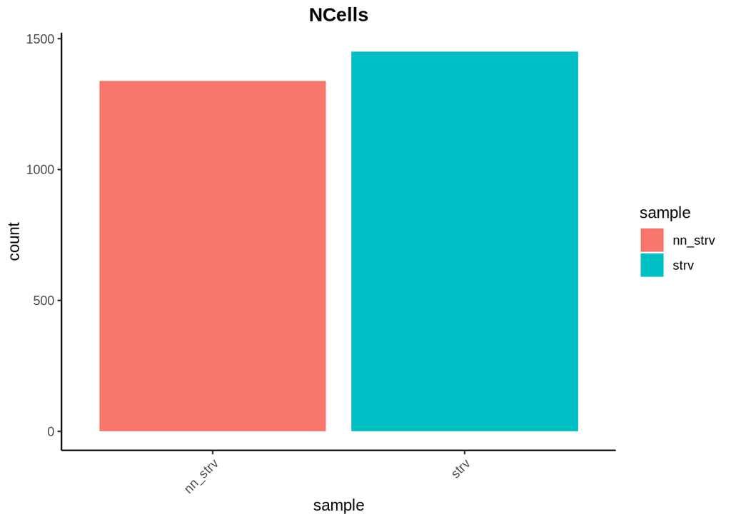

Nous pouvons observer qu’après séquençage chaque échantillon est composé d’un peu moins de 1500 cellules. Cela correspond aux pertes attendues dû au caractéristique des machines et cela indique que peu d’artefact seront présents dans nos données.

##### Nombre de transcrit par cellule

En règle général on s’attend à ce qu’une cellule de bonne qualité contienne plus de 500 transcrits.

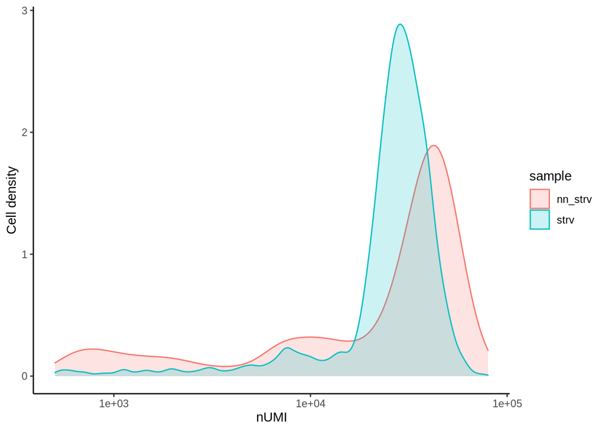

Dans notre cas on observe que le nombre de transcrit moyen par cellule pour nos deux groupes est de l’ordre des $10^{4}$ elles sont donc de très bonne qualité.

##### Nombre de gènes détécté par cellule

En principe nous devons observer un pic unique pour des données de bonne qualité témoignant de la similarité entre nos cellules.

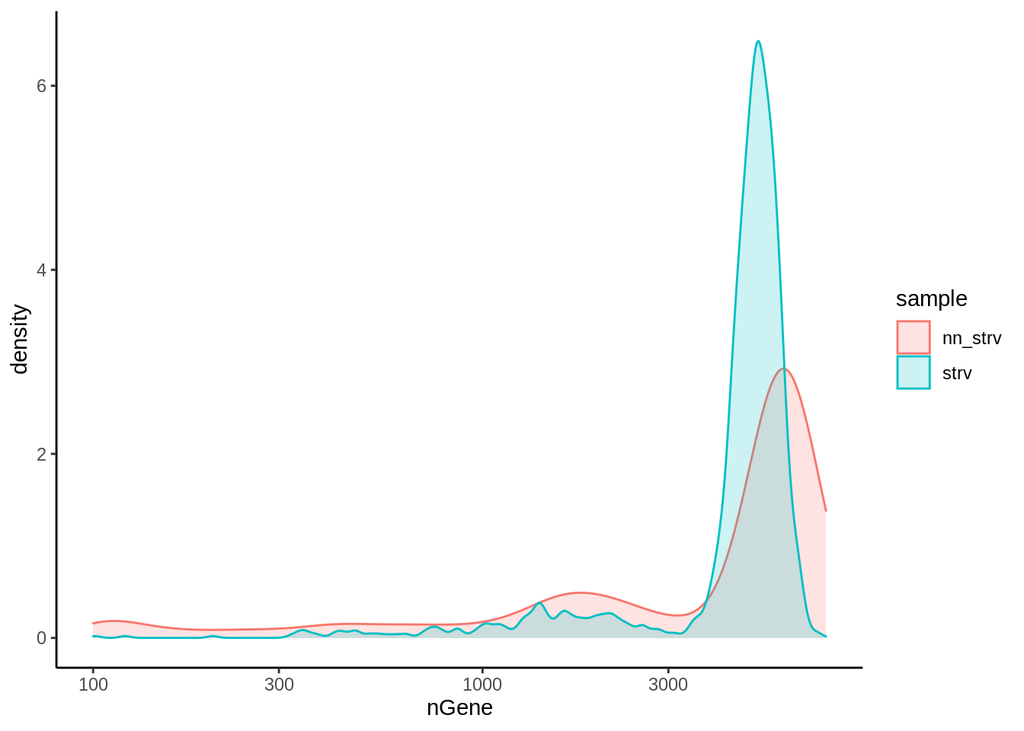

C’est bien le cas pour nos données.

##### Compléxité

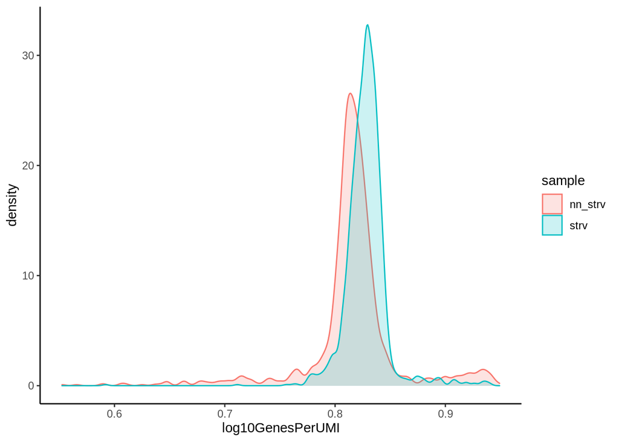

##### Pourcentage de mitochondrie par cellule

Les cellules de faibles qualité ont un taux de mitochondrie supérieur à 20%.

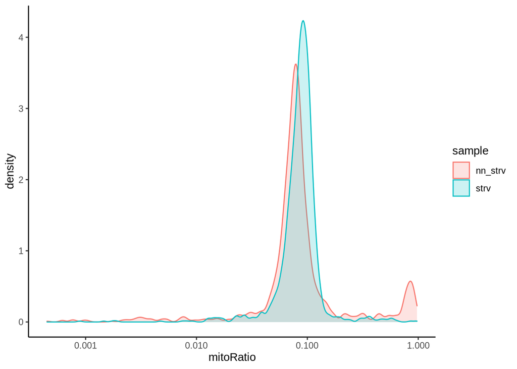

La plupart de nos cellules présentent un taux proche de 10% quelques éléments dépassent la barre des 20%.

##### Effets de bords

Afin d’éviter de surfiltrer nos données nous pouvons vérifier sur un graphique le nombre de gènes contre les nombre de transcrits colorés en fonction du taux de mitochondrie par cellule.

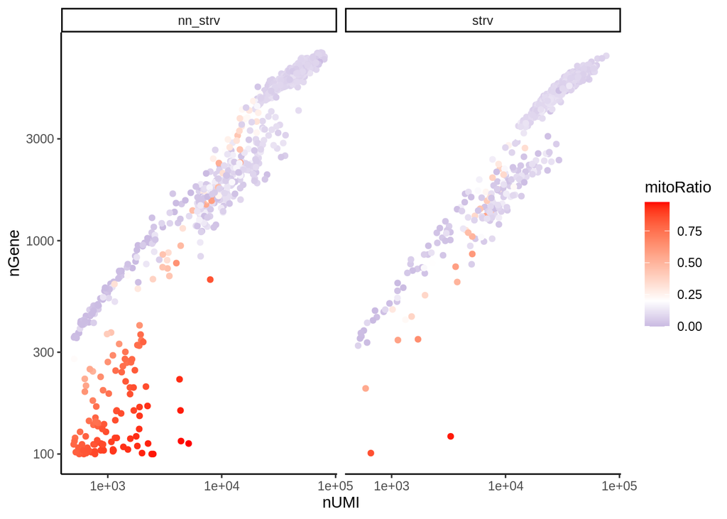

Nous réalisons que les cellules de faibles qualités sont essentiellement celles présentant un fort taux de mitochondrie.

Avec ces éléments en main nous décidons de ne filtrer que les taux de mitochondrie car les cellules semblent être de très bonne qualitées.

#### Après filtrage

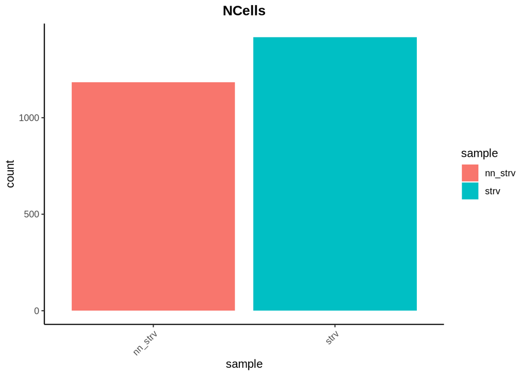

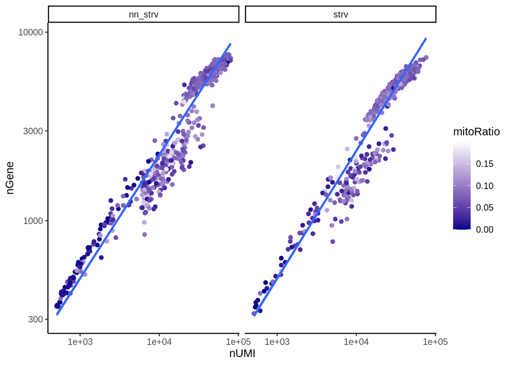